# Risk Factor Analysis

## Outcome Variable

**Outcome Variable:** wasted

## Predictor Variables

**Intervention Variable:** parity

**Adjustment Set:**

- arm
- W_mage
- meducyrs
- feducyrs
- hhwealth_quart
- hfoodsec
- W_mhtcm
- vagbrth
- W_nrooms
- impfloor
- impsan
- safeh20
- delta_W_mage
- delta_meducyrs
- delta_feducyrs
- delta_hhwealth_quart
- delta_hfoodsec
- delta_W_mhtcm
- delta_vagbrth
- delta_W_nrooms
- delta_impfloor
- delta_impsan
- delta_safeh20

## Stratifying Variables

The analysis was stratified on these variable(s):

- agecat
- studyid
- country

## Data Summary

| agecat | studyid | country | parity | wasted | n_cell | n |
| --- | --- | --- | --- | --- | --- | --- |
| Birth | ki1000304b-SAS-CompFeed | INDIA | 1 | 0 | 37 | 166 |
| Birth | ki1000304b-SAS-CompFeed | INDIA | 1 | 1 | 4 | 166 |
| Birth | ki1000304b-SAS-CompFeed | INDIA | 2 | 0 | 41 | 166 |
| Birth | ki1000304b-SAS-CompFeed | INDIA | 2 | 1 | 3 | 166 |
| Birth | ki1000304b-SAS-CompFeed | INDIA | 3+ | 0 | 77 | 166 |
| Birth | ki1000304b-SAS-CompFeed | INDIA | 3+ | 1 | 4 | 166 |
| Birth | ki1101329-Keneba | GAMBIA | 1 | 0 | 139 | 1292 |
| Birth | ki1101329-Keneba | GAMBIA | 1 | 1 | 3 | 1292 |
| Birth | ki1101329-Keneba | GAMBIA | 2 | 0 | 131 | 1292 |
| Birth | ki1101329-Keneba | GAMBIA | 2 | 1 | 2 | 1292 |
| Birth | ki1101329-Keneba | GAMBIA | 3+ | 0 | 996 | 1292 |
| Birth | ki1101329-Keneba | GAMBIA | 3+ | 1 | 21 | 1292 |
| Birth | ki1126311-ZVITAMBO | ZIMBABWE | 1 | 0 | 4497 | 12915 |
| Birth | ki1126311-ZVITAMBO | ZIMBABWE | 1 | 1 | 1064 | 12915 |
| Birth | ki1126311-ZVITAMBO | ZIMBABWE | 2 | 0 | 3358 | 12915 |
| Birth | ki1126311-ZVITAMBO | ZIMBABWE | 2 | 1 | 524 | 12915 |
| Birth | ki1126311-ZVITAMBO | ZIMBABWE | 3+ | 0 | 3000 | 12915 |
| Birth | ki1126311-ZVITAMBO | ZIMBABWE | 3+ | 1 | 472 | 12915 |
| Birth | ki1135781-COHORTS | GUATEMALA | 1 | 0 | 66 | 756 |
| Birth | ki1135781-COHORTS | GUATEMALA | 1 | 1 | 28 | 756 |
| Birth | ki1135781-COHORTS | GUATEMALA | 2 | 0 | 87 | 756 |
| Birth | ki1135781-COHORTS | GUATEMALA | 2 | 1 | 31 | 756 |
| Birth | ki1135781-COHORTS | GUATEMALA | 3+ | 0 | 411 | 756 |
| Birth | ki1135781-COHORTS | GUATEMALA | 3+ | 1 | 133 | 756 |
| Birth | ki1135781-COHORTS | INDIA | 1 | 0 | 505 | 3855 |
| Birth | ki1135781-COHORTS | INDIA | 1 | 1 | 136 | 3855 |
| Birth | ki1135781-COHORTS | INDIA | 2 | 0 | 823 | 3855 |
| Birth | ki1135781-COHORTS | INDIA | 2 | 1 | 159 | 3855 |
| Birth | ki1135781-COHORTS | INDIA | 3+ | 0 | 1876 | 3855 |
| Birth | ki1135781-COHORTS | INDIA | 3+ | 1 | 356 | 3855 |

[output cut: 132 more lines]

The following strata were considered:

- agecat: 24 months, studyid: ki1017093b-PROVIDE, country: BANGLADESH
- agecat: 24 months, studyid: ki1066203-TanzaniaChild2, country: TANZANIA, UNITED REPUBLIC OF
- agecat: 24 months, studyid: ki1101329-Keneba, country: GAMBIA
- agecat: 24 months, studyid: ki1113344-GMS-Nepal, country: NEPAL
- agecat: 24 months, studyid: ki1126311-ZVITAMBO, country: ZIMBABWE
- agecat: 24 months, studyid: ki1135781-COHORTS, country: GUATEMALA
- agecat: 24 months, studyid: ki1135781-COHORTS, country: INDIA
- agecat: 24 months, studyid: ki1135781-COHORTS, country: PHILIPPINES
- agecat: 24 months, studyid: kiGH5241-JiVitA-3, country: BANGLADESH
- agecat: 6 months, studyid: ki1000304b-SAS-CompFeed, country: INDIA
- agecat: 6 months, studyid: ki1000304b-SAS-FoodSuppl, country: INDIA
- agecat: 6 months, studyid: ki1017093b-PROVIDE, country: BANGLADESH
- agecat: 6 months, studyid: ki1066203-TanzaniaChild2, country: TANZANIA, UNITED REPUBLIC OF
- agecat: 6 months, studyid: ki1101329-Keneba, country: GAMBIA
- agecat: 6 months, studyid: ki1113344-GMS-Nepal, country: NEPAL
- agecat: 6 months, studyid: ki1126311-ZVITAMBO, country: ZIMBABWE
- agecat: 6 months, studyid: ki1135781-COHORTS, country: GUATEMALA
- agecat: 6 months, studyid: ki1135781-COHORTS, country: INDIA
- agecat: 6 months, studyid: ki1135781-COHORTS, country: PHILIPPINES
- agecat: 6 months, studyid: kiGH5241-JiVitA-3, country: BANGLADESH
- agecat: Birth, studyid: ki1000304b-SAS-CompFeed, country: INDIA
- agecat: Birth, studyid: ki1101329-Keneba, country: GAMBIA
- agecat: Birth, studyid: ki1126311-ZVITAMBO, country: ZIMBABWE
- agecat: Birth, studyid: ki1135781-COHORTS, country: GUATEMALA
- agecat: Birth, studyid: ki1135781-COHORTS, country: INDIA
- agecat: Birth, studyid: ki1135781-COHORTS, country: PHILIPPINES
- agecat: Birth, studyid: kiGH5241-JiVitA-3, country: BANGLADESH

### Dropped Strata

Some strata were dropped due to rare outcomes:

- agecat: Birth, studyid: ki1000304b-SAS-CompFeed, country: INDIA
- agecat: Birth, studyid: ki1101329-Keneba, country: GAMBIA
- agecat: 6 months, studyid: ki1135781-COHORTS, country: GUATEMALA
- agecat: 24 months, studyid: ki1066203-TanzaniaChild2, country: TANZANIA, UNITED REPUBLIC OF

## Methods Detail

We’re interested in the causal parameters $E[Y_a]$ for all values of $a \in \mathcal{A}$. These parameters represent the mean outcome if, possibly contrary to fact, we intervened to set all units to have $A=a$. Under the randomization and positivity assumptions, these are identified by the statistical parameters $\psi_a=E_W[E_{Y|A,W}(Y|A=a,W)]$. In addition, we’re interested in the mean of $Y$, $E[Y]$ under no intervention (the observed mean). We will estimate these parameters by using SuperLearner to fit the relevant likelihood factors – $E_{Y|A,W}(Y|A=a,W)$ and $p(A=a|W)$, and then updating our likelihood fit using a joint TMLE.

For unadjusted analyses ($W=\{\}$), initial likelihoods were estimated using Lrnr_glm to estimate the simple $E(Y|A)$ and Lrnr_mean to estimate $p(A)$. For adjusted analyses, a small library containing Lrnr_glmnet, Lrnr_xgboost, and Lrnr_mean was used.

Having estimated these parameters, we will then use the delta method to estimate relative risks and attributable risks relative to a prespecified baseline level of $A$.

# Results Detail

## Results Plots

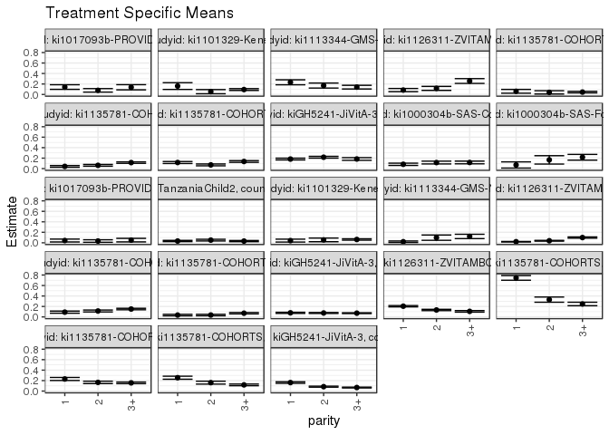

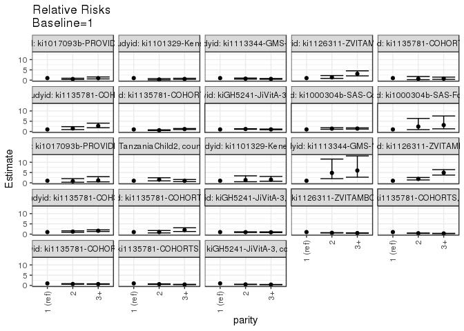

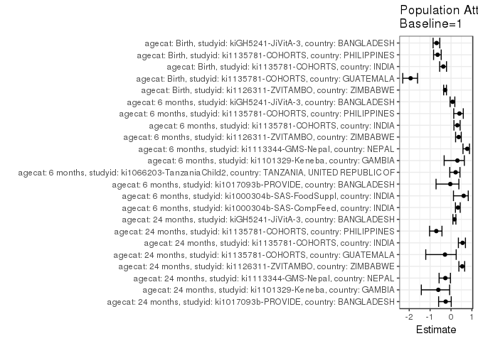

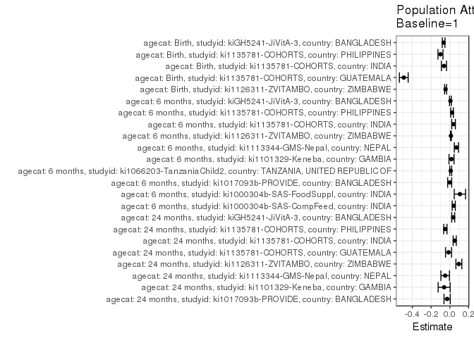

## Results Table

### Parameter: TSM

| agecat | studyid | country | intervention_level | baseline_level | estimate | ci_lower | ci_upper |
| --- | --- | --- | --- | --- | --- | --- | --- |
| Birth | ki1126311-ZVITAMBO | ZIMBABWE | 1 | NA | 0.2046830 | 0.1923772 | 0.2169888 |
| Birth | ki1126311-ZVITAMBO | ZIMBABWE | 2 | NA | 0.1326321 | 0.1204619 | 0.1448022 |
| Birth | ki1126311-ZVITAMBO | ZIMBABWE | 3+ | NA | 0.1062925 | 0.0919861 | 0.1205988 |
| Birth | ki1135781-COHORTS | GUATEMALA | 1 | NA | 0.7451649 | 0.7004884 | 0.7898413 |
| Birth | ki1135781-COHORTS | GUATEMALA | 2 | NA | 0.3301573 | 0.2804832 | 0.3798315 |
| Birth | ki1135781-COHORTS | GUATEMALA | 3+ | NA | 0.2471660 | 0.2140414 | 0.2802906 |
| Birth | ki1135781-COHORTS | INDIA | 1 | NA | 0.2312685 | 0.2022603 | 0.2602767 |
| Birth | ki1135781-COHORTS | INDIA | 2 | NA | 0.1659280 | 0.1433703 | 0.1884858 |
| Birth | ki1135781-COHORTS | INDIA | 3+ | NA | 0.1569660 | 0.1417200 | 0.1722121 |
| Birth | ki1135781-COHORTS | PHILIPPINES | 1 | NA | 0.2553844 | 0.2260910 | 0.2846779 |
| Birth | ki1135781-COHORTS | PHILIPPINES | 2 | NA | 0.1609695 | 0.1331393 | 0.1887997 |
| Birth | ki1135781-COHORTS | PHILIPPINES | 3+ | NA | 0.1185204 | 0.1027606 | 0.1342802 |
| Birth | kiGH5241-JiVitA-3 | BANGLADESH | 1 | NA | 0.1622532 | 0.1470902 | 0.1774162 |
| Birth | kiGH5241-JiVitA-3 | BANGLADESH | 2 | NA | 0.0841952 | 0.0743515 | 0.0940388 |
| Birth | kiGH5241-JiVitA-3 | BANGLADESH | 3+ | NA | 0.0678450 | 0.0602005 | 0.0754895 |
| 6 months | ki1000304b-SAS-CompFeed | INDIA | 1 | NA | 0.0826707 | 0.0609750 | 0.1043665 |
| 6 months | ki1000304b-SAS-CompFeed | INDIA | 2 | NA | 0.1153086 | 0.0887313 | 0.1418859 |
| 6 months | ki1000304b-SAS-CompFeed | INDIA | 3+ | NA | 0.1170630 | 0.0915684 | 0.1425575 |
| 6 months | ki1000304b-SAS-FoodSuppl | INDIA | 1 | NA | 0.0694444 | 0.0106475 | 0.1282414 |
| 6 months | ki1000304b-SAS-FoodSuppl | INDIA | 2 | NA | 0.1666667 | 0.0868626 | 0.2464708 |
| 6 months | ki1000304b-SAS-FoodSuppl | INDIA | 3+ | NA | 0.2165899 | 0.1617098 | 0.2714700 |
| 6 months | ki1017093b-PROVIDE | BANGLADESH | 1 | NA | 0.0426540 | 0.0153646 | 0.0699435 |
| 6 months | ki1017093b-PROVIDE | BANGLADESH | 2 | NA | 0.0330189 | 0.0089451 | 0.0570926 |
| 6 months | ki1017093b-PROVIDE | BANGLADESH | 3+ | NA | 0.0503145 | 0.0163082 | 0.0843208 |
| 6 months | ki1066203-TanzaniaChild2 | TANZANIA, UNITED REPUBLIC OF | 1 | NA | 0.0331818 | 0.0212466 | 0.0451170 |
| 6 months | ki1066203-TanzaniaChild2 | TANZANIA, UNITED REPUBLIC OF | 2 | NA | 0.0505948 | 0.0345844 | 0.0666052 |
| 6 months | ki1066203-TanzaniaChild2 | TANZANIA, UNITED REPUBLIC OF | 3+ | NA | 0.0320621 | 0.0205956 | 0.0435285 |
| 6 months | ki1101329-Keneba | GAMBIA | 1 | NA | 0.0410256 | 0.0131775 | 0.0688738 |
| 6 months | ki1101329-Keneba | GAMBIA | 2 | NA | 0.0548780 | 0.0200120 | 0.0897441 |
| 6 months | ki1101329-Keneba | GAMBIA | 3+ | NA | 0.0625000 | 0.0491515 | 0.0758485 |
| 6 months | ki1113344-GMS-Nepal | NEPAL | 1 | NA | 0.0201828 | 0.0059401 | 0.0344255 |
| 6 months | ki1113344-GMS-Nepal | NEPAL | 2 | NA | 0.0972864 | 0.0468163 | 0.1477564 |
| 6 months | ki1113344-GMS-Nepal | NEPAL | 3+ | NA | 0.1208280 | 0.0791216 | 0.1625344 |
| 6 months | ki1126311-ZVITAMBO | ZIMBABWE | 1 | NA | 0.0202420 | 0.0153646 | 0.0251195 |
| 6 months | ki1126311-ZVITAMBO | ZIMBABWE | 2 | NA | 0.0384362 | 0.0310395 | 0.0458328 |
| 6 months | ki1126311-ZVITAMBO | ZIMBABWE | 3+ | NA | 0.0993697 | 0.0874775 | 0.1112618 |
| 6 months | ki1135781-COHORTS | INDIA | 1 | NA | 0.0913433 | 0.0712868 | 0.1113998 |
| 6 months | ki1135781-COHORTS | INDIA | 2 | NA | 0.1131132 | 0.0948307 | 0.1313958 |
| 6 months | ki1135781-COHORTS | INDIA | 3+ | NA | 0.1504890 | 0.1362475 | 0.1647306 |
| 6 months | ki1135781-COHORTS | PHILIPPINES | 1 | NA | 0.0355897 | 0.0215547 | 0.0496248 |
| 6 months | ki1135781-COHORTS | PHILIPPINES | 2 | NA | 0.0362842 | 0.0225827 | 0.0499858 |
| 6 months | ki1135781-COHORTS | PHILIPPINES | 3+ | NA | 0.0711622 | 0.0575766 | 0.0847477 |
| 6 months | kiGH5241-JiVitA-3 | BANGLADESH | 1 | NA | 0.0782047 | 0.0677435 | 0.0886659 |
| 6 months | kiGH5241-JiVitA-3 | BANGLADESH | 2 | NA | 0.0749930 | 0.0661609 | 0.0838251 |
| 6 months | kiGH5241-JiVitA-3 | BANGLADESH | 3+ | NA | 0.0719423 | 0.0637927 | 0.0800920 |
| 24 months | ki1017093b-PROVIDE | BANGLADESH | 1 | NA | 0.1411177 | 0.0971935 | 0.1850420 |
| 24 months | ki1017093b-PROVIDE | BANGLADESH | 2 | NA | 0.0784088 | 0.0449554 | 0.1118622 |
| 24 months | ki1017093b-PROVIDE | BANGLADESH | 3+ | NA | 0.1371668 | 0.0878471 | 0.1864866 |
| 24 months | ki1101329-Keneba | GAMBIA | 1 | NA | 0.1600543 | 0.0957555 | 0.2243530 |
| 24 months | ki1101329-Keneba | GAMBIA | 2 | NA | 0.0531173 | 0.0138419 | 0.0923927 |
| 24 months | ki1101329-Keneba | GAMBIA | 3+ | NA | 0.0935782 | 0.0762268 | 0.1109296 |
| 24 months | ki1113344-GMS-Nepal | NEPAL | 1 | NA | 0.2321110 | 0.1846298 | 0.2795923 |
| 24 months | ki1113344-GMS-Nepal | NEPAL | 2 | NA | 0.1699558 | 0.1219733 | 0.2179383 |
| 24 months | ki1113344-GMS-Nepal | NEPAL | 3+ | NA | 0.1393850 | 0.1041888 | 0.1745811 |
| 24 months | ki1126311-ZVITAMBO | ZIMBABWE | 1 | NA | 0.0834699 | 0.0533744 | 0.1135655 |
| 24 months | ki1126311-ZVITAMBO | ZIMBABWE | 2 | NA | 0.1157512 | 0.0777380 | 0.1537644 |
| 24 months | ki1126311-ZVITAMBO | ZIMBABWE | 3+ | NA | 0.2561975 | 0.2106582 | 0.3017367 |
| 24 months | ki1135781-COHORTS | GUATEMALA | 1 | NA | 0.0598802 | 0.0238784 | 0.0958821 |
| 24 months | ki1135781-COHORTS | GUATEMALA | 2 | NA | 0.0397351 | 0.0085646 | 0.0709056 |
| 24 months | ki1135781-COHORTS | GUATEMALA | 3+ | NA | 0.0448549 | 0.0301129 | 0.0595968 |
| 24 months | ki1135781-COHORTS | INDIA | 1 | NA | 0.0422363 | 0.0261249 | 0.0583477 |
| 24 months | ki1135781-COHORTS | INDIA | 2 | NA | 0.0623746 | 0.0456855 | 0.0790636 |
| 24 months | ki1135781-COHORTS | INDIA | 3+ | NA | 0.1146063 | 0.1005984 | 0.1286143 |
| 24 months | ki1135781-COHORTS | PHILIPPINES | 1 | NA | 0.1161502 | 0.0974200 | 0.1348804 |
| 24 months | ki1135781-COHORTS | PHILIPPINES | 2 | NA | 0.0707841 | 0.0530655 | 0.0885026 |
| 24 months | ki1135781-COHORTS | PHILIPPINES | 3+ | NA | 0.1356256 | 0.1189472 | 0.1523039 |
| 24 months | kiGH5241-JiVitA-3 | BANGLADESH | 1 | NA | 0.1822069 | 0.1653002 | 0.1991136 |
| 24 months | kiGH5241-JiVitA-3 | BANGLADESH | 2 | NA | 0.2173580 | 0.2005224 | 0.2341936 |
| 24 months | kiGH5241-JiVitA-3 | BANGLADESH | 3+ | NA | 0.1836440 | 0.1583693 | 0.2089188 |

### Parameter: E(Y)

| agecat | studyid | country | intervention_level | baseline_level | estimate | ci_lower | ci_upper |
| --- | --- | --- | --- | --- | --- | --- | --- |
| Birth | ki1126311-ZVITAMBO | ZIMBABWE | NA | NA | 0.1595045 | 0.1531895 | 0.1658194 |
| Birth | ki1135781-COHORTS | GUATEMALA | NA | NA | 0.2539683 | 0.2229196 | 0.2850169 |
| Birth | ki1135781-COHORTS | INDIA | NA | NA | 0.1688716 | 0.1570438 | 0.1806994 |
| Birth | ki1135781-COHORTS | PHILIPPINES | NA | NA | 0.1555709 | 0.1423748 | 0.1687670 |
| Birth | kiGH5241-JiVitA-3 | BANGLADESH | NA | NA | 0.0959725 | 0.0907703 | 0.1011747 |
| 6 months | ki1000304b-SAS-CompFeed | INDIA | NA | NA | 0.1244378 | 0.0992652 | 0.1496104 |
| 6 months | ki1000304b-SAS-FoodSuppl | INDIA | NA | NA | 0.1769437 | 0.1381636 | 0.2157238 |
| 6 months | ki1017093b-PROVIDE | BANGLADESH | NA | NA | 0.0412371 | 0.0250690 | 0.0574052 |
| 6 months | ki1066203-TanzaniaChild2 | TANZANIA, UNITED REPUBLIC OF | NA | NA | 0.0426279 | 0.0337587 | 0.0514970 |
| 6 months | ki1101329-Keneba | GAMBIA | NA | NA | 0.0591497 | 0.0476693 | 0.0706302 |
| 6 months | ki1113344-GMS-Nepal | NEPAL | NA | NA | 0.0905861 | 0.0668565 | 0.1143158 |
| 6 months | ki1126311-ZVITAMBO | ZIMBABWE | NA | NA | 0.0320707 | 0.0282716 | 0.0358698 |
| 6 months | ki1135781-COHORTS | INDIA | NA | NA | 0.1311552 | 0.1210467 | 0.1412637 |
| 6 months | ki1135781-COHORTS | PHILIPPINES | NA | NA | 0.0594974 | 0.0505830 | 0.0684118 |
| 6 months | kiGH5241-JiVitA-3 | BANGLADESH | NA | NA | 0.0846689 | 0.0798658 | 0.0894720 |
| 24 months | ki1017093b-PROVIDE | BANGLADESH | NA | NA | 0.1124567 | 0.0866788 | 0.1382347 |
| 24 months | ki1101329-Keneba | GAMBIA | NA | NA | 0.0995640 | 0.0837378 | 0.1153901 |
| 24 months | ki1113344-GMS-Nepal | NEPAL | NA | NA | 0.1827309 | 0.1487560 | 0.2167058 |
| 24 months | ki1126311-ZVITAMBO | ZIMBABWE | NA | NA | 0.1800948 | 0.1433886 | 0.2168010 |
| 24 months | ki1135781-COHORTS | GUATEMALA | NA | NA | 0.0464684 | 0.0338852 | 0.0590516 |
| 24 months | ki1135781-COHORTS | INDIA | NA | NA | 0.0945140 | 0.0846121 | 0.1044160 |
| 24 months | ki1135781-COHORTS | PHILIPPINES | NA | NA | 0.0681911 | 0.0582056 | 0.0781766 |
| 24 months | kiGH5241-JiVitA-3 | BANGLADESH | NA | NA | 0.2182836 | 0.2083649 | 0.2282022 |

### Parameter: RR

| agecat | studyid | country | intervention_level | baseline_level | estimate | ci_lower | ci_upper |
| --- | --- | --- | --- | --- | --- | --- | --- |
| Birth | ki1126311-ZVITAMBO | ZIMBABWE | 1 | 1 | 1.0000000 | 1.0000000 | 1.0000000 |
| Birth | ki1126311-ZVITAMBO | ZIMBABWE | 2 | 1 | 0.6479878 | 0.5806738 | 0.7231050 |
| Birth | ki1126311-ZVITAMBO | ZIMBABWE | 3+ | 1 | 0.5193030 | 0.4481845 | 0.6017067 |
| Birth | ki1135781-COHORTS | GUATEMALA | 1 | 1 | 1.0000000 | 1.0000000 | 1.0000000 |
| Birth | ki1135781-COHORTS | GUATEMALA | 2 | 1 | 0.4430661 | 0.3776739 | 0.5197807 |
| Birth | ki1135781-COHORTS | GUATEMALA | 3+ | 1 | 0.3316930 | 0.2867725 | 0.3836500 |
| Birth | ki1135781-COHORTS | INDIA | 1 | 1 | 1.0000000 | 1.0000000 | 1.0000000 |
| Birth | ki1135781-COHORTS | INDIA | 2 | 1 | 0.7174692 | 0.5963535 | 0.8631828 |
| Birth | ki1135781-COHORTS | INDIA | 3+ | 1 | 0.6787178 | 0.5792348 | 0.7952869 |
| Birth | ki1135781-COHORTS | PHILIPPINES | 1 | 1 | 1.0000000 | 1.0000000 | 1.0000000 |
| Birth | ki1135781-COHORTS | PHILIPPINES | 2 | 1 | 0.6303027 | 0.5122830 | 0.7755117 |
| Birth | ki1135781-COHORTS | PHILIPPINES | 3+ | 1 | 0.4640863 | 0.3893671 | 0.5531440 |
| Birth | kiGH5241-JiVitA-3 | BANGLADESH | 1 | 1 | 1.0000000 | 1.0000000 | 1.0000000 |
| Birth | kiGH5241-JiVitA-3 | BANGLADESH | 2 | 1 | 0.5189122 | 0.4470157 | 0.6023722 |
| Birth | kiGH5241-JiVitA-3 | BANGLADESH | 3+ | 1 | 0.4181426 | 0.3613438 | 0.4838695 |
| 6 months | ki1000304b-SAS-CompFeed | INDIA | 1 | 1 | 1.0000000 | 1.0000000 | 1.0000000 |
| 6 months | ki1000304b-SAS-CompFeed | INDIA | 2 | 1 | 1.3947929 | 1.0690099 | 1.8198589 |
| 6 months | ki1000304b-SAS-CompFeed | INDIA | 3+ | 1 | 1.4160143 | 1.1475559 | 1.7472756 |
| 6 months | ki1000304b-SAS-FoodSuppl | INDIA | 1 | 1 | 1.0000000 | 1.0000000 | 1.0000000 |
| 6 months | ki1000304b-SAS-FoodSuppl | INDIA | 2 | 1 | 2.4000000 | 0.9073519 | 6.3481435 |
| 6 months | ki1000304b-SAS-FoodSuppl | INDIA | 3+ | 1 | 3.1188940 | 1.2887863 | 7.5477991 |
| 6 months | ki1017093b-PROVIDE | BANGLADESH | 1 | 1 | 1.0000000 | 1.0000000 | 1.0000000 |
| 6 months | ki1017093b-PROVIDE | BANGLADESH | 2 | 1 | 0.7741090 | 0.2934517 | 2.0420557 |
| 6 months | ki1017093b-PROVIDE | BANGLADESH | 3+ | 1 | 1.1795947 | 0.4651051 | 2.9916758 |
| 6 months | ki1066203-TanzaniaChild2 | TANZANIA, UNITED REPUBLIC OF | 1 | 1 | 1.0000000 | 1.0000000 | 1.0000000 |
| 6 months | ki1066203-TanzaniaChild2 | TANZANIA, UNITED REPUBLIC OF | 2 | 1 | 1.5247758 | 0.9442256 | 2.4622728 |
| 6 months | ki1066203-TanzaniaChild2 | TANZANIA, UNITED REPUBLIC OF | 3+ | 1 | 0.9662545 | 0.5816102 | 1.6052807 |
| 6 months | ki1101329-Keneba | GAMBIA | 1 | 1 | 1.0000000 | 1.0000000 | 1.0000000 |
| 6 months | ki1101329-Keneba | GAMBIA | 2 | 1 | 1.3376523 | 0.5279118 | 3.3894177 |
| 6 months | ki1101329-Keneba | GAMBIA | 3+ | 1 | 1.5234373 | 0.7477881 | 3.1036350 |
| 6 months | ki1113344-GMS-Nepal | NEPAL | 1 | 1 | 1.0000000 | 1.0000000 | 1.0000000 |
| 6 months | ki1113344-GMS-Nepal | NEPAL | 2 | 1 | 4.8202646 | 2.0092644 | 11.5639087 |
| 6 months | ki1113344-GMS-Nepal | NEPAL | 3+ | 1 | 5.9866864 | 2.7371409 | 13.0941064 |
| 6 months | ki1126311-ZVITAMBO | ZIMBABWE | 1 | 1 | 1.0000000 | 1.0000000 | 1.0000000 |
| 6 months | ki1126311-ZVITAMBO | ZIMBABWE | 2 | 1 | 1.8988279 | 1.3953214 | 2.5840263 |
| 6 months | ki1126311-ZVITAMBO | ZIMBABWE | 3+ | 1 | 4.9090726 | 3.7540562 | 6.4194547 |
| 6 months | ki1135781-COHORTS | INDIA | 1 | 1 | 1.0000000 | 1.0000000 | 1.0000000 |
| 6 months | ki1135781-COHORTS | INDIA | 2 | 1 | 1.2383309 | 0.9433413 | 1.6255658 |
| 6 months | ki1135781-COHORTS | INDIA | 3+ | 1 | 1.6475106 | 1.2975086 | 2.0919253 |
| 6 months | ki1135781-COHORTS | PHILIPPINES | 1 | 1 | 1.0000000 | 1.0000000 | 1.0000000 |
| 6 months | ki1135781-COHORTS | PHILIPPINES | 2 | 1 | 1.0195139 | 0.5909145 | 1.7589832 |
| 6 months | ki1135781-COHORTS | PHILIPPINES | 3+ | 1 | 1.9995133 | 1.2901799 | 3.0988340 |
| 6 months | kiGH5241-JiVitA-3 | BANGLADESH | 1 | 1 | 1.0000000 | 1.0000000 | 1.0000000 |
| 6 months | kiGH5241-JiVitA-3 | BANGLADESH | 2 | 1 | 0.9589315 | 0.8016497 | 1.1470716 |
| 6 months | kiGH5241-JiVitA-3 | BANGLADESH | 3+ | 1 | 0.9199231 | 0.7738034 | 1.0936350 |
| 24 months | ki1017093b-PROVIDE | BANGLADESH | 1 | 1 | 1.0000000 | 1.0000000 | 1.0000000 |
| 24 months | ki1017093b-PROVIDE | BANGLADESH | 2 | 1 | 0.5556269 | 0.3279794 | 0.9412826 |
| 24 months | ki1017093b-PROVIDE | BANGLADESH | 3+ | 1 | 0.9720031 | 0.6051169 | 1.5613348 |
| 24 months | ki1101329-Keneba | GAMBIA | 1 | 1 | 1.0000000 | 1.0000000 | 1.0000000 |
| 24 months | ki1101329-Keneba | GAMBIA | 2 | 1 | 0.3318707 | 0.1429591 | 0.7704176 |
| 24 months | ki1101329-Keneba | GAMBIA | 3+ | 1 | 0.5846657 | 0.3757889 | 0.9096434 |
| 24 months | ki1113344-GMS-Nepal | NEPAL | 1 | 1 | 1.0000000 | 1.0000000 | 1.0000000 |
| 24 months | ki1113344-GMS-Nepal | NEPAL | 2 | 1 | 0.7322176 | 0.5166161 | 1.0377970 |
| 24 months | ki1113344-GMS-Nepal | NEPAL | 3+ | 1 | 0.6005098 | 0.4339564 | 0.8309868 |
| 24 months | ki1126311-ZVITAMBO | ZIMBABWE | 1 | 1 | 1.0000000 | 1.0000000 | 1.0000000 |
| 24 months | ki1126311-ZVITAMBO | ZIMBABWE | 2 | 1 | 1.3867413 | 0.8608887 | 2.2337981 |
| 24 months | ki1126311-ZVITAMBO | ZIMBABWE | 3+ | 1 | 3.0693377 | 2.0776432 | 4.5343849 |
| 24 months | ki1135781-COHORTS | GUATEMALA | 1 | 1 | 1.0000000 | 1.0000000 | 1.0000000 |
| 24 months | ki1135781-COHORTS | GUATEMALA | 2 | 1 | 0.6635762 | 0.2469743 | 1.7829113 |
| 24 months | ki1135781-COHORTS | GUATEMALA | 3+ | 1 | 0.7490765 | 0.3775276 | 1.4862905 |
| 24 months | ki1135781-COHORTS | INDIA | 1 | 1 | 1.0000000 | 1.0000000 | 1.0000000 |
| 24 months | ki1135781-COHORTS | INDIA | 2 | 1 | 1.4768011 | 0.9275595 | 2.3512686 |
| 24 months | ki1135781-COHORTS | INDIA | 3+ | 1 | 2.7134577 | 1.8180198 | 4.0499297 |
| 24 months | ki1135781-COHORTS | PHILIPPINES | 1 | 1 | 1.0000000 | 1.0000000 | 1.0000000 |
| 24 months | ki1135781-COHORTS | PHILIPPINES | 2 | 1 | 0.6094185 | 0.4531714 | 0.8195372 |
| 24 months | ki1135781-COHORTS | PHILIPPINES | 3+ | 1 | 1.1676739 | 0.9520007 | 1.4322073 |
| 24 months | kiGH5241-JiVitA-3 | BANGLADESH | 1 | 1 | 1.0000000 | 1.0000000 | 1.0000000 |
| 24 months | kiGH5241-JiVitA-3 | BANGLADESH | 2 | 1 | 1.1929183 | 1.0582508 | 1.3447229 |
| 24 months | kiGH5241-JiVitA-3 | BANGLADESH | 3+ | 1 | 1.0078872 | 0.8541743 | 1.1892615 |

### Parameter: PAR

| agecat | studyid | country | intervention_level | baseline_level | estimate | ci_lower | ci_upper |
| --- | --- | --- | --- | --- | --- | --- | --- |
| Birth | ki1126311-ZVITAMBO | ZIMBABWE | 1 | NA | -0.0451785 | -0.0557268 | -0.0346302 |
| Birth | ki1135781-COHORTS | GUATEMALA | 1 | NA | -0.4911966 | -0.5380024 | -0.4443908 |
| Birth | ki1135781-COHORTS | INDIA | 1 | NA | -0.0623969 | -0.0895006 | -0.0352932 |
| Birth | ki1135781-COHORTS | PHILIPPINES | 1 | NA | -0.0998135 | -0.1265076 | -0.0731195 |
| Birth | kiGH5241-JiVitA-3 | BANGLADESH | 1 | NA | -0.0662807 | -0.0808625 | -0.0516989 |
| 6 months | ki1000304b-SAS-CompFeed | INDIA | 1 | NA | 0.0417670 | 0.0252469 | 0.0582872 |
| 6 months | ki1000304b-SAS-FoodSuppl | INDIA | 1 | NA | 0.1074993 | 0.0472802 | 0.1677183 |
| 6 months | ki1017093b-PROVIDE | BANGLADESH | 1 | NA | -0.0014169 | -0.0230072 | 0.0201734 |
| 6 months | ki1066203-TanzaniaChild2 | TANZANIA, UNITED REPUBLIC OF | 1 | NA | 0.0094461 | -0.0011006 | 0.0199928 |
| 6 months | ki1101329-Keneba | GAMBIA | 1 | NA | 0.0181241 | -0.0087267 | 0.0449749 |
| 6 months | ki1113344-GMS-Nepal | NEPAL | 1 | NA | 0.0704034 | 0.0480353 | 0.0927714 |
| 6 months | ki1126311-ZVITAMBO | ZIMBABWE | 1 | NA | 0.0118286 | 0.0072829 | 0.0163744 |
| 6 months | ki1135781-COHORTS | INDIA | 1 | NA | 0.0398119 | 0.0202043 | 0.0594195 |
| 6 months | ki1135781-COHORTS | PHILIPPINES | 1 | NA | 0.0239077 | 0.0100076 | 0.0378077 |
| 6 months | kiGH5241-JiVitA-3 | BANGLADESH | 1 | NA | 0.0064641 | -0.0031590 | 0.0160873 |
| 24 months | ki1017093b-PROVIDE | BANGLADESH | 1 | NA | -0.0286610 | -0.0621958 | 0.0048739 |
| 24 months | ki1101329-Keneba | GAMBIA | 1 | NA | -0.0604903 | -0.1243802 | 0.0033996 |
| 24 months | ki1113344-GMS-Nepal | NEPAL | 1 | NA | -0.0493801 | -0.0948337 | -0.0039265 |
| 24 months | ki1126311-ZVITAMBO | ZIMBABWE | 1 | NA | 0.0966248 | 0.0652387 | 0.1280109 |
| 24 months | ki1135781-COHORTS | GUATEMALA | 1 | NA | -0.0134118 | -0.0458485 | 0.0190249 |
| 24 months | ki1135781-COHORTS | INDIA | 1 | NA | 0.0522777 | 0.0356992 | 0.0688563 |
| 24 months | ki1135781-COHORTS | PHILIPPINES | 1 | NA | -0.0479591 | -0.0656450 | -0.0302732 |
| 24 months | kiGH5241-JiVitA-3 | BANGLADESH | 1 | NA | 0.0360766 | 0.0203427 | 0.0518106 |

### Parameter: PAF

| agecat | studyid | country | intervention_level | baseline_level | estimate | ci_lower | ci_upper |
| --- | --- | --- | --- | --- | --- | --- | --- |
| Birth | ki1126311-ZVITAMBO | ZIMBABWE | 1 | NA | -0.2832431 | -0.3520776 | -0.2179129 |
| Birth | ki1135781-COHORTS | GUATEMALA | 1 | NA | -1.9340866 | -2.3092207 | -1.6014779 |
| Birth | ki1135781-COHORTS | INDIA | 1 | NA | -0.3694931 | -0.5435852 | -0.2150359 |
| Birth | ki1135781-COHORTS | PHILIPPINES | 1 | NA | -0.6415953 | -0.8341857 | -0.4692270 |
| Birth | kiGH5241-JiVitA-3 | BANGLADESH | 1 | NA | -0.6906221 | -0.8571252 | -0.5390471 |
| 6 months | ki1000304b-SAS-CompFeed | INDIA | 1 | NA | 0.3356460 | 0.2123723 | 0.4396258 |
| 6 months | ki1000304b-SAS-FoodSuppl | INDIA | 1 | NA | 0.6075337 | 0.1176744 | 0.8254275 |
| 6 months | ki1017093b-PROVIDE | BANGLADESH | 1 | NA | -0.0343602 | -0.7156685 | 0.3763941 |
| 6 months | ki1066203-TanzaniaChild2 | TANZANIA, UNITED REPUBLIC OF | 1 | NA | 0.2215941 | -0.0593871 | 0.4280507 |
| 6 months | ki1101329-Keneba | GAMBIA | 1 | NA | 0.3064102 | -0.3277241 | 0.6376756 |
| 6 months | ki1113344-GMS-Nepal | NEPAL | 1 | NA | 0.7771979 | 0.5735976 | 0.8835823 |
| 6 months | ki1126311-ZVITAMBO | ZIMBABWE | 1 | NA | 0.3688301 | 0.2195958 | 0.4895268 |
| 6 months | ki1135781-COHORTS | INDIA | 1 | NA | 0.3035480 | 0.1407267 | 0.4355168 |
| 6 months | ki1135781-COHORTS | PHILIPPINES | 1 | NA | 0.4018271 | 0.1319531 | 0.5877978 |
| 6 months | kiGH5241-JiVitA-3 | BANGLADESH | 1 | NA | 0.0763461 | -0.0443612 | 0.1831021 |
| 24 months | ki1017093b-PROVIDE | BANGLADESH | 1 | NA | -0.2548620 | -0.5927230 | 0.0113292 |
| 24 months | ki1101329-Keneba | GAMBIA | 1 | NA | -0.6075522 | -1.4209536 | -0.0674406 |
| 24 months | ki1113344-GMS-Nepal | NEPAL | 1 | NA | -0.2702340 | -0.5695058 | -0.0280271 |
| 24 months | ki1126311-ZVITAMBO | ZIMBABWE | 1 | NA | 0.5365221 | 0.3773158 | 0.6550230 |
| 24 months | ki1135781-COHORTS | GUATEMALA | 1 | NA | -0.2886228 | -1.2084474 | 0.2480923 |
| 24 months | ki1135781-COHORTS | INDIA | 1 | NA | 0.5531216 | 0.3540447 | 0.6908450 |
| 24 months | ki1135781-COHORTS | PHILIPPINES | 1 | NA | -0.7033045 | -1.0257484 | -0.4321848 |
| 24 months | kiGH5241-JiVitA-3 | BANGLADESH | 1 | NA | 0.1652742 | 0.0911479 | 0.2333548 |